# Weather events impact analysis

Tomas Lancinger

july 2015

### Abstract

*This R Markdown dowcument is a study elaborated under Coursera course “Reproducible Research”, Peer Assessment 2.*

The subject of this study is to analyze impacts of weather events on economy and public health using the database of U.S. National and Atmospheric Administration (NOAA) collected between 1950 and 2011. We will focus on identification of the events with the most substantial impacts in matter of losses or injuries.

### Data processing

The data set [Storm Data Documentation](https://d396qusza40orc.cloudfront.net/repdata%2Fpeer2_doc%2Fpd01016005curr.pdf) is downloaded and unzipped in working directory.

```r
   library(R.utils)
```

```r
   library(R.utils)
library(ggplot2)
library(plyr)
library(gridExtra)
   # Set working directory of your choice
   setwd("D:\\R\\wd\\Storm_analysis")

   # Download data, store them to working directory
   if (!"stormData.csv.bz2" %in% dir("./data/")) {
       # download.file("http://d396qusza40orc.cloudfront.net/repdata%2Fdata%2FStormData.csv.bz2", destfile = "stormData.csv.bz2")

       # Unzip the downloaded data
       bunzip2("stormData.csv.bz2", remove=F,overwrite=T)
   }
```

Load the obtained data to data set

```r
storms <- read.csv("stormData.csv", sep = ",")
```

Data source ranges from 1950 to 2011 but data from these two years are incomplete. Nevertheless, we proceed to further analysis. Let’s check the storms frequency.

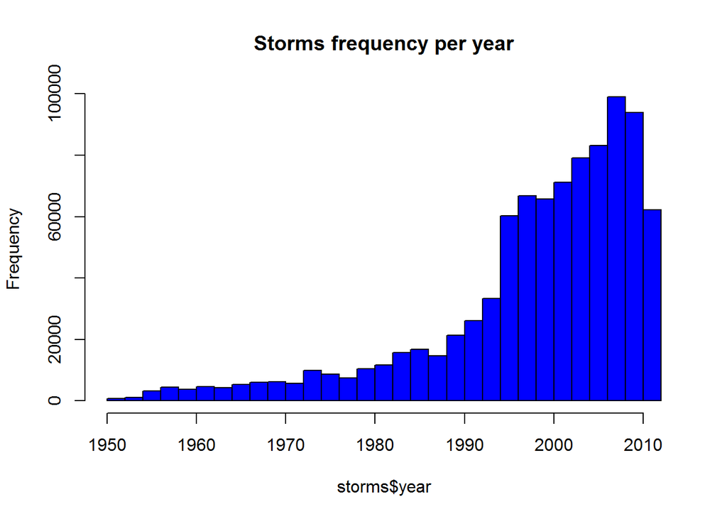

```r
options(scipen = 1)

if (dim(storms)[2] == 37) {
    storms$year <- as.numeric(format(as.Date(storms$BGN_DATE, format = "%m/%d/%Y %H:%M:%S"), "%Y"))
}

hist(storms$year,
     col="blue",
     main = "Storms frequency per year",
     breaks = 30
     )
```

Obviously, the number of storms (or at least observations recorded in the database) increased in 1995. Let’s focus on these years to increase the analysis relevancy.

```r
storm <- storms[storms$year >= 1995, ]
```

#### Health impacts

The impact to public health is based on occurance of injuries an fatalities in the data. Let’s check the top 20 event types by severity.

```r
customFilter <- function(fieldName, top = 20, dataset = storms) {
    index <- which(colnames(dataset) == fieldName)
    field <- aggregate(dataset[, index], by = list(dataset$EVTYPE), FUN = "sum")
    names(field) <- c("EVTYPE", fieldName)
    field <- arrange(field, field[, 2], decreasing = T)
    field <- head(field, n = top)
    field <- within(field, EVTYPE <- factor(x = EVTYPE, levels = field$EVTYPE))
    return(field)
}

injuries <- customFilter("INJURIES", dataset = storm)

fatalities <- customFilter("FATALITIES", dataset = storm)
```

#### Economy impacts

Economy impacts are based on property and crops damages. The units have to coverted to make them comparable.

```r
convert <- function(dataset = storm, fieldName, newFieldName) {
    totalLen <- dim(dataset)[2]
    index <- which(colnames(dataset) == fieldName)
    dataset[, index] <- as.character(dataset[, index])
    logic <- !is.na(toupper(dataset[, index]))
    dataset[logic & toupper(dataset[, index]) == "B", index] <- "9"
    dataset[logic & toupper(dataset[, index]) == "M", index] <- "6"
    dataset[logic & toupper(dataset[, index]) == "K", index] <- "3"
    dataset[logic & toupper(dataset[, index]) == "H", index] <- "2"
    dataset[logic & toupper(dataset[, index]) == "", index] <- "0"
    dataset[, index] <- as.numeric(dataset[, index])
    dataset[is.na(dataset[, index]), index] <- 0
    dataset <- cbind(dataset, dataset[, index - 1] * 10^dataset[, index])
    names(dataset)[totalLen + 1] <- newFieldName
    return(dataset)
}

storm <- convert(storm, "PROPDMGEXP", "propertyDamage")
storm <- convert(storm, "CROPDMGEXP", "cropDamage")
options(scipen=999)

property <- customFilter("propertyDamage", dataset = storm)
crop <- customFilter("cropDamage", dataset = storm)
```

#### Analysis output

Graph of fatalities and injuries to depict the most influential events. (apologize the X axis formatting issues in the latest release)

[figure not shown]

```r
fatalitiesPlot <- qplot(EVTYPE,
                        data = fatalities,
                        weight = FATALITIES,
                        geom = "bar",
                        binwidth = 1
                       )
                        + scale_y_continuous("Number of Fatalities")
                        + theme(axis.text.x = element_text(angle = 45,hjust = 1))
                        + xlab("Weather event ype")
                       + ggtitle("Total fatalities by Weather events in the U.S.\n from 1995 - 2011"


injuriesPlot <- qplot(EVTYPE,
                      data = injuries,
                      weight = INJURIES,
                      geom = "bar",
                      binwidth = 1
                      )
                       + scale_y_continuous("Number of Injuries")
                       + theme(axis.text.x = element_text(angle = 45, hjust = 1))
                       + xlab("Weather event ype")
                       + ggtitle("Total injuries by Weather events in the U.S.\n from 1995 - 2011"


grid.arrange(fatalitiesPlot, injuriesPlot, ncol = 2)
```

Reciprocally, below is presented the graph to depict the most economical losses.

[figure not shown]

```r
propertyPlot <- qplot(EVTYPE,
                      data = property,
                      weight = propertyDamage,
                      geom = "bar",
                      binwidth = 1
                    )
                    + theme(axis.text.x = element_text(angle = 45, hjust = 1))
                    + scale_y_continuous("Property Damage in US dollars")
                    + xlab("Severe Weather Type")
                    + ggtitle("Total Property Damage by\n Severe Weather Events in\n the U.S. from 1995 - 2011")

cropPlot<- qplot(EVTYPE,
                 data = crop,
                 weight = cropDamage,
                 geom = "bar",
                 binwidth = 1
                )
              + theme(axis.text.x = element_text(angle = 45, hjust = 1))
                + scale_y_continuous("Crop Damage in US dollars")
                + xlab("Severe Weather Type")
                + ggtitle("Total Crop Damage by \nSevere Weather Events in\n the U.S. from 1995 - 2011")

grid.arrange(propertyPlot, cropPlot, ncol = 2)
```